# Wine Reviews

### 5.price属性的处理，为数值属性。

含缺失值，因此先去掉空值后计算五叔概括并计算离群点。

```
五数概括：
Min: 4.0
Q1: 17.0
Q2: 25.0
Q3: 42.0
Max: 3300.0
```

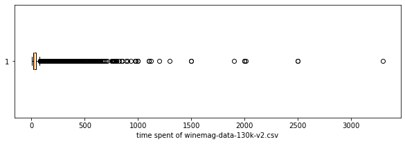

```
离群点： 79.5
```

```python
attribute_5 = attributes_150[5]
del_price = whole_data_after_fill_4[0].dropna(subset=[attribute_5])
figure_of_time_spent(np.array(del_price[attribute_5]), 0)
```

```
五数概括：
Min: 4.0
Q1: 16.0
Q2: 24.0
Q3: 40.0
Max: 2300.0
```

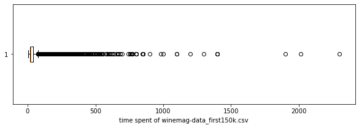

```
离群点： 76.0
```

```python
del_price = whole_data_after_fill_4[1].dropna(subset=[attribute_5])
figure_of_time_spent(np.array(del_price[attribute_5]), 1)
```

处理缺失值

首先，通过属性的相关关系来填补缺失值：

按照同一个酒庄winery，同一款酒designation的已有数据price来进行补充。

以winery和designation作为key，price作为value来建立dict。

```python
def build_dict_2_key(key1, key2, value):
    dict_ = dict()
    for current_file in file_path_arr:
        data = pd.read_csv(current_file, keep_default_na=False, low_memory=False)
        index_key = data[data[key2] != ''].index
        for i in index_key:
            if data.loc[i, value] != '':
                key_ = data.loc[i, key1] + data.loc[i, key2]
                if key_ not in dict_:
                    dict_[key_] = data.loc[i, value]
    return  dict_

attribute_3 = attributes_150[3]
print(attribute_10)
print(attribute_3)
print(attribute_5)
winery_designation_price_dict = build_dict_2_key(attribute_10, attribute_3, attribute_5)
```

```
winery
designation
price
```

```python
def fill_from_dict_2_key(current_file, dict_, key1, key2, value):
    print("current file name: ", current_file)
    cnt = 0
    data = pd.read_csv(current_file, keep_default_na=False, low_memory=False)
    index_key = data[data[value] == ''].index
    print(index_key)
    for i in index_key:
        key_ = data.loc[i, key1] + data.loc[i, key2]
        if key_ in dict_:
            data.loc[i, value] = dict_[key_]
            # print(key_, dict_[key_])
        else:
            cnt += 1

    print("There'are " + str(cnt) + "keys don't exist.")
    data.to_csv(current_file, index = False)
```

```python
fill_from_dict_2_key(file_path_arr[0], winery_designation_price_dict, attribute_10, attribute_3, attribute_5)
```

```
current file name:  winemag-data-130k-v2.csv
Int64Index([     0,     13,     30,     31,     32,     50,     54,     79,
               137,    159,
            ...
            129702, 129725, 129732, 129745, 129751, 129782, 129798, 129801,
            129831, 129901],
           dtype='int64', length=8992)
There'are 6574keys don't exist.
```

```python
fill_from_dict_2_key(file_path_arr[1], winery_designation_price_dict, attribute_10, attribute_3, attribute_5)
```

```
current file name:  winemag-data_first150k.csv
Int64Index([    32,     56,     72,     82,    116,    242,    261,    282,
               294,    323,
            ...
            150250, 150255, 150256, 150314, 150317, 150372, 150373, 150582,
            150668, 150917],
           dtype='int64', length=13695)
There'are 9913keys don't exist.
```

查看第一次填充后的price盒图分布：

```
五数概括：
Min: 4.0
Q1: 17.0
Q2: 25.0
Q3: 42.0
Max: 3300.0
```

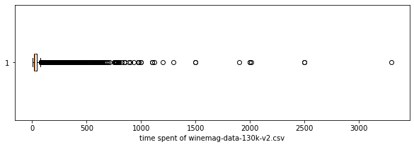

```
离群点： 79.5
```

```python
whole_data_after_fill_5 = []
for current_file in file_path_arr:
        whole_data_after_fill_5.append(pd.read_csv(current_file, low_memory=False))

fill_price = whole_data_after_fill_5[0].dropna(subset=[attribute_5])
figure_of_time_spent(np.array(fill_price[attribute_5]), 0)
```

```
五数概括：
Min: 4.0
Q1: 16.0
Q2: 24.0
Q3: 40.0
Max: 2300.0
```

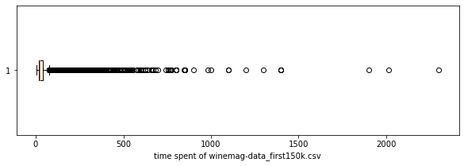

```
离群点： 76.0
```

```python
fill_price = whole_data_after_fill_5[1].dropna(subset=[attribute_5])
figure_of_time_spent(np.array(fill_price[attribute_5]), 1)
```

price在第一次处理后仍然存在空值，因此，使用频数最高的值来对其进行填充：

```python
def check_frequency(file_index, attribute_, whole_data_):
    print("current file name: ", file_path_arr[file_index])
    current_data = whole_data_[file_index]
    print(current_data[attribute_].value_counts(dropna = False))

check_frequency(0, attribute_5, whole_data_after_fill_5)
```

```
current file name:  winemag-data-130k-v2.csv
20.0     7087
NaN      6574
15.0     6197
25.0     5893
30.0     5032
         ...
428.0       1
269.0       1
276.0       1
672.0       1
540.0       1
Name: price, Length: 391, dtype: int64
```

```python
current_file = file_path_arr[0]
print("current file name: ", current_file)
data = pd.read_csv(current_file, keep_default_na=False, low_memory=False)
index_key = data[data[attribute_5] == ''].index
print(index_key)
for i in index_key:
    data.loc[i, attribute_5] = "20.0"

data.to_csv(current_file, index = False)
```

```
current file name:  winemag-data-130k-v2.csv
Int64Index([     0,     13,    163,    182,    194,    222,    223,    285,
               288,    290,
            ...
            129548, 129622, 129659, 129696, 129702, 129725, 129745, 129751,
            129798, 129801],
           dtype='int64', length=6574)
```

```python
check_frequency(1, attribute_5, whole_data_after_fill_5)
```

```
current file name:  winemag-data_first150k.csv
NaN       9913
20.0      8055
15.0      7264
18.0      6126
25.0      6124
          ...
545.0        1
319.0        1
698.0        1
1900.0       1
540.0        1
Name: price, Length: 363, dtype: int64
```

```python
current_file = file_path_arr[1]
print("current file name: ", current_file)
data = pd.read_csv(current_file, keep_default_na=False, low_memory=False)
index_key = data[data[attribute_5] == ''].index
print(index_key)
for i in index_key:
    data.loc[i, attribute_5] = "20.0"

data.to_csv(current_file, index = False)
```

```
current file name:  winemag-data_first150k.csv
Int64Index([    56,     72,     82,    116,    242,    261,    282,    374,
               375,    434,
            ...
            150250, 150255, 150256, 150314, 150317, 150372, 150373, 150582,
            150668, 150917],
           dtype='int64', length=9913)
```

```python
whole_data_after_fill_6 = []
for current_file in file_path_arr:
        whole_data_after_fill_6.append(pd.read_csv(current_file, low_memory=False))

check_frequency(0, attribute_5, whole_data_after_fill_6)
```

```
current file name:  winemag-data-130k-v2.csv
20.0      13661
15.0       6197
25.0       5893
30.0       5032
18.0       4977
          ...
247.0         1
630.0         1
1900.0        1
602.0         1
540.0         1
Name: price, Length: 390, dtype: int64
```

```python
check_frequency(1, attribute_5, whole_data_after_fill_6)
```

```
current file name:  winemag-data_first150k.csv
20.0     17968
15.0      7264
18.0      6126
25.0      6124
30.0      5574
         ...
545.0        1
351.0        1
319.0        1
698.0        1
540.0        1
Name: price, Length: 362, dtype: int64
```

查看第二次填充后的price盒图分布：

```
五数概括：
Min: 4.0
Q1: 18.0
Q2: 25.0
Q3: 40.0
Max: 3300.0
```

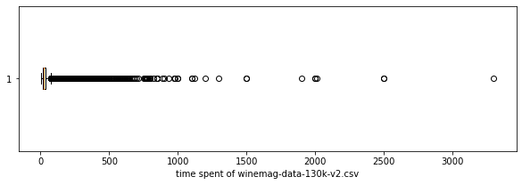

```
离群点： 73.0
```

```python
fill_price = whole_data_after_fill_6[0].dropna(subset=[attribute_5])
figure_of_time_spent(np.array(fill_price[attribute_5]), 0)
```

```
五数概括：
Min: 4.0
Q1: 16.0
Q2: 23.0
Q3: 39.0
Max: 2300.0
```

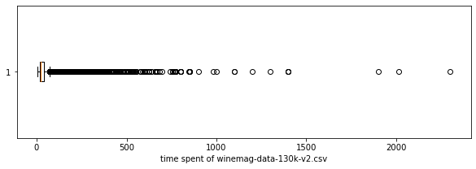

```
离群点： 73.5
```

```python
fill_price = whole_data_after_fill_6[1].dropna(subset=[attribute_5])
figure_of_time_spent(np.array(fill_price[attribute_5]), 0)
```

### 6.taster_name& taster_twitter_handle属性的处理，为标称属性。

这两个属性代表了评价者的姓名和社交网站的地址，可认为对评分的数据影响不大，暂时不处理，输出频数直方图：

```
current file name:  winemag-data-130k-v2.csv
NaN                   26244
Roger Voss            25512
Michael Schachner     15127
Kerin O’Keefe         10776
Virginie Boone         9537
Paul Gregutt           9531
Matt Kettmann          6332
Joe Czerwinski         5145
Sean P. Sullivan       4966
Anna Lee C. Iijima     4415
Jim Gordon             4177
Anne Krebiehl MW       3676
Lauren Buzzeo          1832
Susan Kostrzewa        1080
Mike DeSimone           502
Jeff Jenssen            469
Alexander Peartree      415
Carrie Dykes            139
Fiona Adams              27
Christina Pickard         6
Name: taster_name, dtype: int64
```

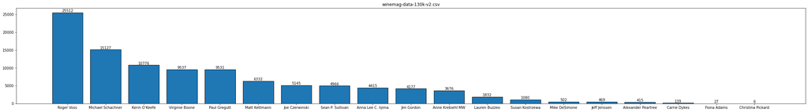

```python
attribute = attributes_130[9]
figure_by_attribute(0, attribute, whole_data_after_fill_6)
```

```
current file name:  winemag-data-130k-v2.csv
NaN                 31213
@vossroger          25512
@wineschach         15127
@kerinokeefe        10776
@vboone              9537
@paulgwine           9531
@mattkettmann        6332
@JoeCz               5145
@wawinereport        4966
@gordone_cellars     4177
@AnneInVino          3676
@laurbuzz            1832
@suskostrzewa        1080
@worldwineguys        971
@bkfiona               27
@winewchristina         6
Name: taster_twitter_handle, dtype: int64
```

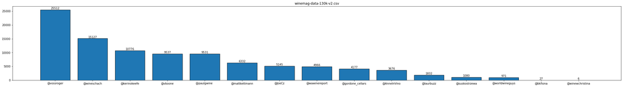

```python
attribute = attributes_130[10]
figure_by_attribute(0, attribute, whole_data_after_fill_6)
```

### 7.variety属性的处理，为标称属性。

输出频数直方图：

```
current file name:  winemag-data-130k-v2.csv
Pinot Noir                  13269
Chardonnay                  11750
Cabernet Sauvignon           9470
Red Blend                    8935
Bordeaux-style Red Blend     6915
                            ...
Parraleta                       1
Malagouzia-Chardonnay           1
Pinotage-Merlot                 1
Molinara                        1
NaN                             1
Name: variety, Length: 702, dtype: int64
```

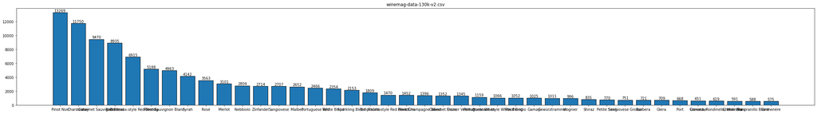

```python
attribute = attributes_150[9]
figure_by_attribute(0, attribute, whole_data_after_fill_6)
```

```
current file name:  winemag-data_first150k.csv
Chardonnay                  14482
Pinot Noir                  14288
Cabernet Sauvignon          12800
Red Blend                   10061
Bordeaux-style Red Blend     7347
                            ...
Cabernet Franc-Malbec           1
Azal                            1
Moscatel Graúdo                 1
Sacy                            1
Freisa                          1
Name: variety, Length: 632, dtype: int64
```

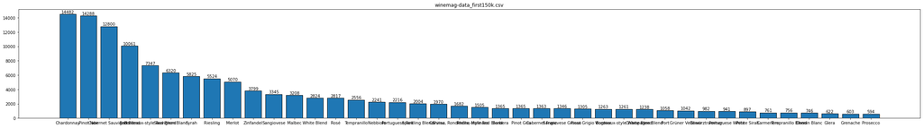

```python
figure_by_attribute(1, attribute, whole_data_after_fill_6)
```

从上面的图像我们可以看到，该属性只有一个缺失值（130k），那么我们使用频数最高的那个种类对它进行填充：

```python
current_file = file_path_arr[0]
print("current file name: ", current_file)
cnt = 0
data = pd.read_csv(current_file, keep_default_na=False, low_memory=False)
index_key = data[data[attribute] == ''].index
print(index_key)
for i in index_key:
    data.loc[i, attribute] = "Pinot Noir"

data.to_csv(current_file, index = False)
```

```
current file name:  winemag-data-130k-v2.csv
Int64Index([86867], dtype='int64')
```

```
current file name:  winemag-data-130k-v2.csv
Pinot Noir                  13270
Chardonnay                  11750
Cabernet Sauvignon           9470
Red Blend                    8935
Bordeaux-style Red Blend     6915
                            ...
Parraleta                       1
Malagouzia-Chardonnay           1
Pinotage-Merlot                 1
Molinara                        1
Espadeiro                       1
Name: variety, Length: 701, dtype: int64
```

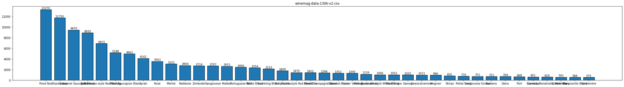

```python
whole_data_after_fill_7 = []
for current_file in file_path_arr:
        whole_data_after_fill_7.append(pd.read_csv(current_file, low_memory=False))

figure_by_attribute(0, attribute, whole_data_after_fill_7)
```